# Informe técnico: Salud y Felicidad percibida en Europa

Alba Sarasa Gracia

01/09/2025

# 1. Introducción

Este informe forma parte del proyecto de Ciencia de Datos reproducible del Máster en Behavioral Data Science por el Instituto de Formación Continua IL3 de la Universidad de Barcelona.  
Su principal objetivo es **analizar algunos de los factores sociodemográficos y contextuales que influyen en la felicidad y la salud autopercibidas en Europa**, con el fin de identificar patrones y relaciones relevantes.

Los objetivos específicos del proyecto son:

# 2. Datos y metodología

Los análisis se basan en los datos de la encuesta [European Social Survey](https://ess.sikt.no/en/) “ESS11 edition 3.0”, descargados el 20/08/2025.

Se han seleccionado las variables de felicidad (`happy`), salud (`health`), edad (`agea`), género (`gndr`), y lugar de nacimiento (`brncntr`).  
Los análisis combinan **tablas resumen, pruebas estadísticas y gráficos descriptivos**.

# 3. Resultados principales

## 3.1. Relación entre salud autopercibida y felicidad

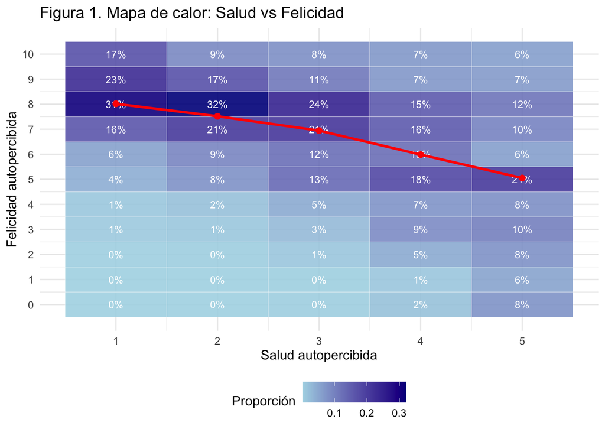

Tabla 1. Test de correlación de Spearman entre health y happy

|  | p_value | rho |
| --- | --- | --- |
| rho | 0 | -0.282 |

En base a estos hallazgos, se exploran más a fondo estas variables mediante el análisis conjunto con factores sociodemográficos como la edad, el género y la situación de inmigación.

## 3.2. Interacción con factores sociodemográficos:

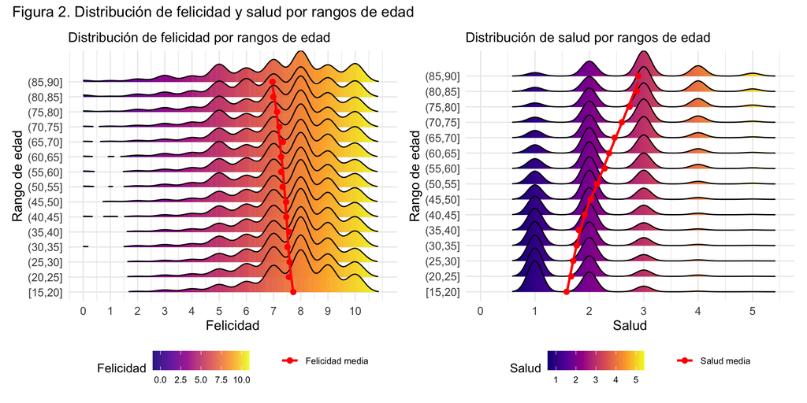

En las tablas siguientes (Tabla 2 y Tabla 3) se observa que, aunque existen ligeras diferencias en los niveles altos de felicidad y salud entre hombres y mujeres, la distribución general es bastante similar entre ambos géneros.

Tabla 2. Distribución porcentual de felicidad por género

|  | Hombre | Mujer |
| --- | --- | --- |
| 0 | 0.48 | 0.48 |
| 1 | 0.40 | 0.37 |
| 2 | 0.97 | 1.06 |
| 3 | 1.99 | 2.13 |
| 4 | 2.86 | 2.98 |
| 5 | 9.14 | 8.92 |
| 6 | 9.31 | 9.44 |
| 7 | 19.55 | 18.94 |
| 8 | 29.10 | 28.02 |
| 9 | 16.15 | 16.48 |
| 10 | 10.07 | 11.19 |

Tabla 3. Distribución porcentual de salud por género

| Hombre | Mujer |
| --- | --- |
| 27.47 | 24.13 |
| 42.73 | 41.45 |
| 23.19 | 26.40 |
| 5.57 | 6.70 |
| 1.04 | 1.32 |

Finalmente, se muestra en la Tabla 4 y Tabla 5 que la población no nacida en el país tiende a reportar niveles más altos de felicidad, mientras que la población nativa puntúa más alto en salud percibida. Esto refuerza la hipótesis de una relación inversa entre salud y felicidad percibidas.

Tabla 4. Distribución porcentual de felicidad por condición migratoria

|  | Nacido en el país | No nacido en el país |
| --- | --- | --- |
| 0 | 0.50 | 0.30 |
| 1 | 0.40 | 0.23 |
| 2 | 1.02 | 0.97 |
| 3 | 2.11 | 1.58 |
| 4 | 2.99 | 2.25 |
| 5 | 9.17 | 7.60 |
| 6 | 9.47 | 8.41 |
| 7 | 19.45 | 17.08 |
| 8 | 28.63 | 27.59 |
| 9 | 16.12 | 18.40 |
| 10 | 10.15 | 15.59 |

Tabla 5. Distribución porcentual de salud por condición migratoria

| Nacido en el país | No nacido en el país |
| --- | --- |
| 25.56 | 26.97 |
| 41.86 | 43.83 |
| 25.15 | 22.53 |
| 6.22 | 5.71 |
| 1.21 | 0.97 |

# 4. Conclusiones

**Relación entre salud y felicidad:**

- Se ha detectado una tendencia monótona negativa: a menor salud media percibida, mayor felicidad media reportada. La mayoría de las respuestas se concentran en los valores de salud medio-bajos y de felicidad medio-altos.

**Relación entre edad y felicidad/salud:**

- La felicidad tiende a disminuir ligeramente con la edad, mientras que la salud percibida aumenta, reforzando la relación inversa entre ambas variables.

**Diferencias de género en felicidad y salud:**

- Las diferencias entre hombres y mujeres son sutiles; las mujeres puntúan ligeramente más alto en niveles altos de felicidad y salud, pero las distribuciones generales son similares.

**Condición migratoria y niveles de felicidad/salud:**